# Usage of AMOUNTAIN

Dong Li dxl466@cs.bham.ac.uk

14 November 2016

# 1 Motivation

There are various ways to detect modules from weighted networks. Conventional approaches such as clustering or graph partitioning purely use the network topology to define modules (Fortunato 2010). But we may need additional information such as increasing high-throughput omics data. On the one hand, the construction of reliable networks, especially for specific tissues, is relatively slow. On the other hand, integrating omics data with network topology has become a paradigm in system biology community in the past decade (Mitra et al. 2013). Weighted gene co-expression network (WGCN) is a pure data-driven gene network, which only relies on gene expression profiles. There is no rigorous definition of *active modules* in WGCN, but the module itself should be more *compact* and *informative* compared with random subnetworks. AMOUNTAIN (D. Li et al. 2016) provides a convex optimization based approach to identify such modules. Here we embed parts of the examples from the corresponding package AMOUNTAIN help pages into a single document.

# 2 Network simulation

We follow (W. Li et al. 2011) to construct gene co-expression networks for simulation study. Let $n$ be the number of genes, and edge weights $W$ as well as node score $z$ follow the uniform distribution in range $[0,1]$. A module contains $k$ genes inside which the edge weights as well as node score follow the uniform distribution in range $[\theta,1]$, where $\theta=\{0.5,0.6,0.7,0.8,0.9\}$.

```r
library(AMOUNTAIN)
n = 100
k = 20
theta = 0.5
pp <- networkSimulation(n, k, theta)
moduleid <- pp[[3]]
netid <- 1:100
restp <- netid[-moduleid]
groupdesign <- list(moduleid,restp)
names(groupdesign) <- c('module','background')
```

The following figure shows the weighted co-expression network when $n=100,k=20$ and red nodes indicate module members and wider edges mean larger similarities. Visualization is based on [qgraph](https://cran.r-project.org/web/packages/qgraph/index.html).

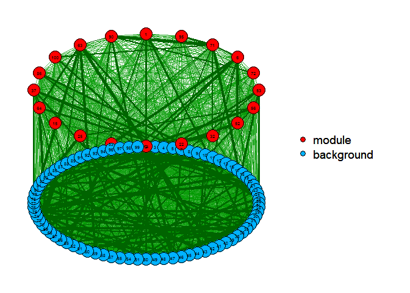

```r
require(qgraph)
pg <- qgraph(pp[[1]],groups=groupdesign,legend=TRUE)
```

When simulating a two-layer network, the basic method is to connect two independent networks with an inter-layer weight matrix $A$, which is designed to have larger weights between two modules.

```r
n1 = 100
k1 = 20
theta1 = 0.5
n2 = 80
k2 = 10
theta2 = 0.5
ppresult <- twolayernetworkSimulation(n1,k1,theta1,n2,k2,theta2)
A <- ppresult[[3]]
pp <- ppresult[[1]]
moduleid <- pp[[3]]
netid <- 1:n1
restp <- netid[-moduleid]
pp2 <- ppresult[[2]]
moduleid2 <- pp2[[3]]
netid2 <- 1:n2
restp2 <- netid2[-moduleid2]

library(qgraph)
## labelling the groups
groupdesign <- list(moduleid,restp,(moduleid2+n1),(restp2+n1))
names(groupdesign) <- c('module1','background1','module2',
                     'background2')
twolayernet <- matrix(0,nrow=(n1+n2),ncol=(n1+n2))
twolayernet[1:n1,1:n1] <- pp[[1]]
twolayernet[(n1+1):(n1+n2),(n1+1):(n1+n2)] <- pp2[[1]]
twolayernet[1:n1,(n1+1):(n1+n2)] <- A
twolayernet[(n1+1):(n1+n2),1:n1] <- t(A)
```

The following figure shows the the two-layer weighted co-expression network based on above simulation.

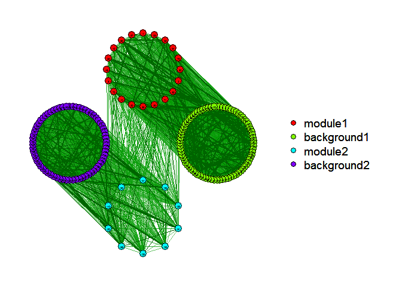

```r
g <- qgraph(twolayernet,groups=groupdesign,legend=TRUE)
```

# 3 Module identification for single layer network

Given the network $G$ with edges weight matrix $W\in\mathbb{R}^{n\times n}$ and nodes weight vector ${\bf z}\in\mathbb{R}^{n}$, where $n$ is the number of nodes, we formulate the active modules identification on WGCN as a elastic net contrained optmization problem:

$$\min_{{\bf x}\in \mathbb{R}_+^n}\ F({\bf x})=-{\bf x}^TW{\bf x}-\lambda{\bf z}^T{\bf x}\quad s.t.\quad \alpha\|{\bf x}\|_1+(1-\alpha)\|{\bf x}\|_2^2=1$$

where the module membership vector ${\bf x}\in\mathbb{R}_+^n$ is relaxed from a $0-1$ vector in which $x_i\neq0$ means node $i$ is in the module. And $\alpha$ is the parameter to balance $\ell_1$-norm and $\ell_2$-norm which actually controls the module size. Larger $\alpha$ means a more sparse vector, corresponding smaller module in this case. We adopt the euclidean projection based technique (Gong, Gai, and Zhang 2011) to solve the problem.

```r
n = 100
k = 20
theta = 0.5
pp <- networkSimulation(n,k,theta)
moduleid <- pp[[3]]
alphaset <- seq(0.1,0.9,by=0.1)
lambdaset <- 2^seq(-5,5)
## using a grid search to select lambda and alpha
Fscores <- matrix(0,nrow = length(alphaset),ncol = length(lambdaset))
for (j in 1:length(alphaset)) {
    for (k in 1:length(lambdaset)) {
        x <- moduleIdentificationGPFixSS(pp[[1]],pp[[2]],rep(1/n,n),maxiter = 500,
                                         a=alphaset[j],lambda = lambdaset[k])
        predictedid<-which(x[[2]]!=0)
        recall <- length(intersect(predictedid,moduleid))/length(moduleid)
        precise <- length(intersect(predictedid,moduleid))/length(predictedid)
        Fscores[j,k] <- 2*precise*recall/(precise+recall)
    }
}
```

We can show $gridFscore$ by 3-D plot to see how these parameters affect the performance. By certain combination of these two parameters, we can almost exactly find the target model nodes with $F-score=1$.

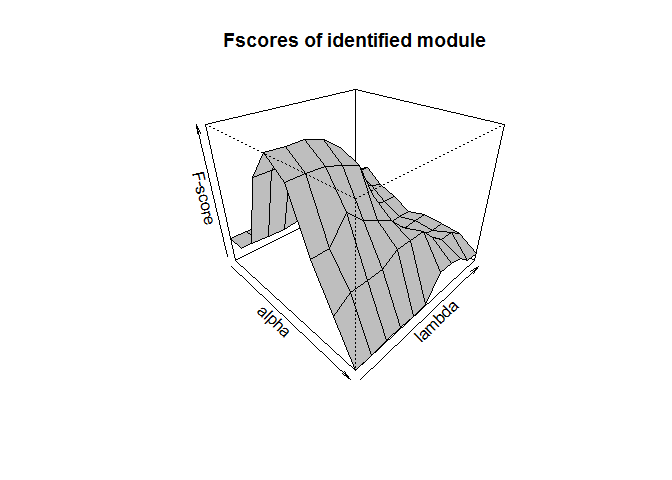

```r
persp(Fscores,theta = 45,phi = 30,col = "gray",scale = FALSE,xlab = 'alpha',ylab = 'lambda',
      zlab = 'F-score',main = 'Fscores of identified module',box = TRUE)
```

# 4 Module identification for two-layer network

```r
## network simulation is the same as before
modres <- moduleIdentificationGPFixSSTwolayer(pp[[1]],pp[[2]],rep(1/n1,n1),pp2[[1]],pp2[[2]],rep(1/n2,n2),A)
predictedid <- which(modres[[1]]!=0)
recall <- length(intersect(predictedid,moduleid))/length(moduleid)
precise <- length(intersect(predictedid,moduleid))/length(predictedid)
F1 <- 2*precise*recall/(precise+recall)
predictedid2 <- which(modres[[2]]!=0)
recall2 <- length(intersect(predictedid2,moduleid2))/length(moduleid2)
precise2 <- length(intersect(predictedid2,moduleid2))/length(predictedid2)
F2 <- 2*precise2*recall2/(precise2+recall2)
```